신록예찬

# (연구) 2D decomposition with SSA

진행형

May 20, 2021 • 최규빈 • 5 min read

연구

- Import packages
- Testsignal 1
  - SSA
  - 2D PCA
- Testsignal 2
  - SSA
    - window size = (64,64)
    - window size = (8,8)
  - 2D-PCA
- TestSignal 3
  - SSA
  - 2D-PCA
- Discussion

## Import packages

```r
library(Rssa)
```

## Testsignal 1

`-` composite of two components having different frequencies

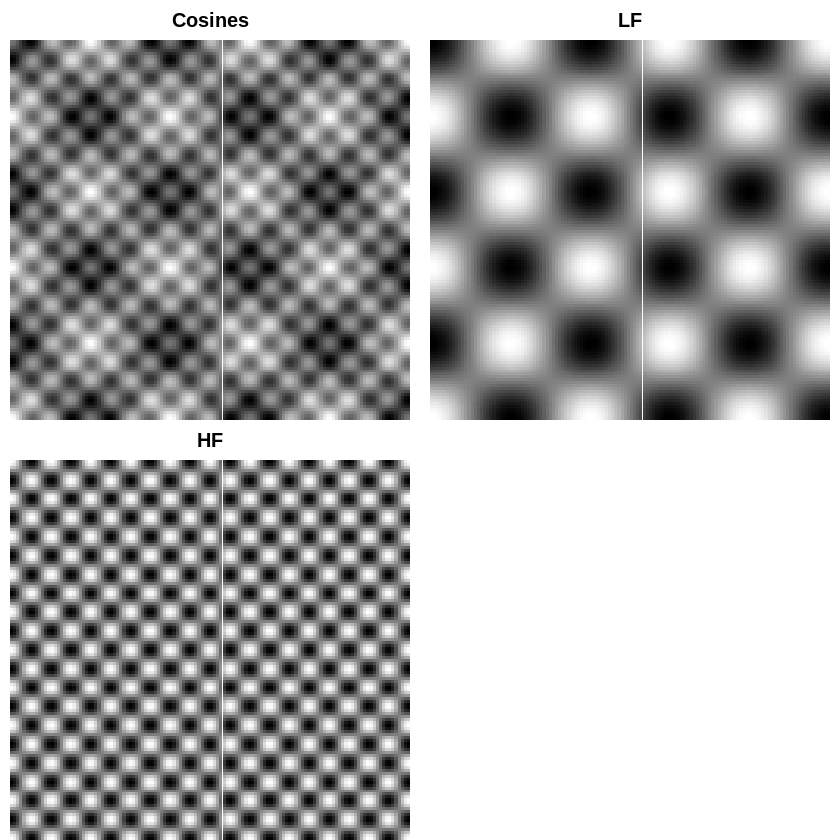

```r
nr <- nc <- 128; x <- y <- seq(0, 1, length=nr)

coscomp1 <- outer(cos(20 * pi * x), cos(20 * pi * y))
coscomp2 <- outer(cos(5* pi * x), cos(5 * pi * y))
cosmeanf <- coscomp1 + coscomp2

par(mfcol=c(2,2), mar=c(0,0.5,2,0.5))
image(cosmeanf, xlab="", ylab="", col=gray(0:100/100), axes=F, main="Cosines")
image(coscomp1, xlab="", ylab="", col=gray(0:100/100), axes=F, main="HF")
image(coscomp2, xlab="", ylab="", col=gray(0:100/100), axes=F, main="LF")
```

### SSA

`-` Apply SSA to Testsignal 1

- Reference: Golyandina, N., Korobeynikov, A., Shlemov, A., & Usevich, K. (2013). Multivariate and 2D extensions of singular spectrum analysis with the Rssa package. arXiv preprint arXiv:1309.5050.

`-` Window size is 64*64

`-` The window size can be interpreted as a multiscale parameter.

- Small window size: Focusing on local changes, advantageous for judging sudden changes in signals; Suitable for analyzing partial normal time series
- Large window size: Focus on global structure; Suitable for analyzing stationary time series

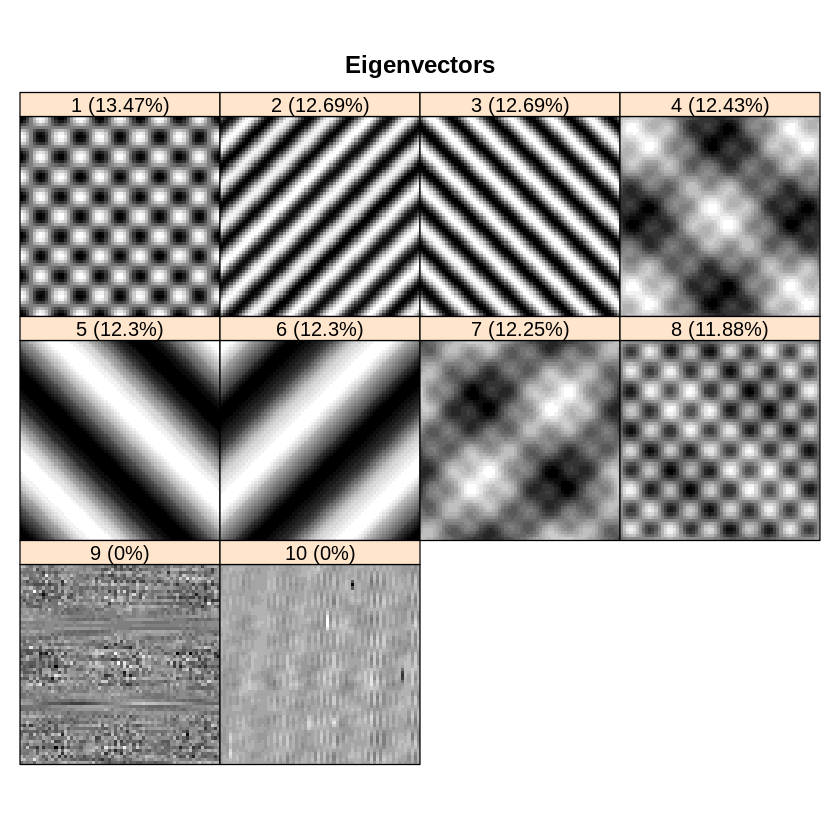

```r
ssarslt<-ssa(cosmeanf, kind="2d-ssa",L=c(64,64))
plot(ssarslt,type="vectors")
```

`-` Interpretation of ssa results: Some are considered low-frequency and some are considered high-frequency.

- low-freq: 4,5,6,7
- high-freq: 1,2,3,8

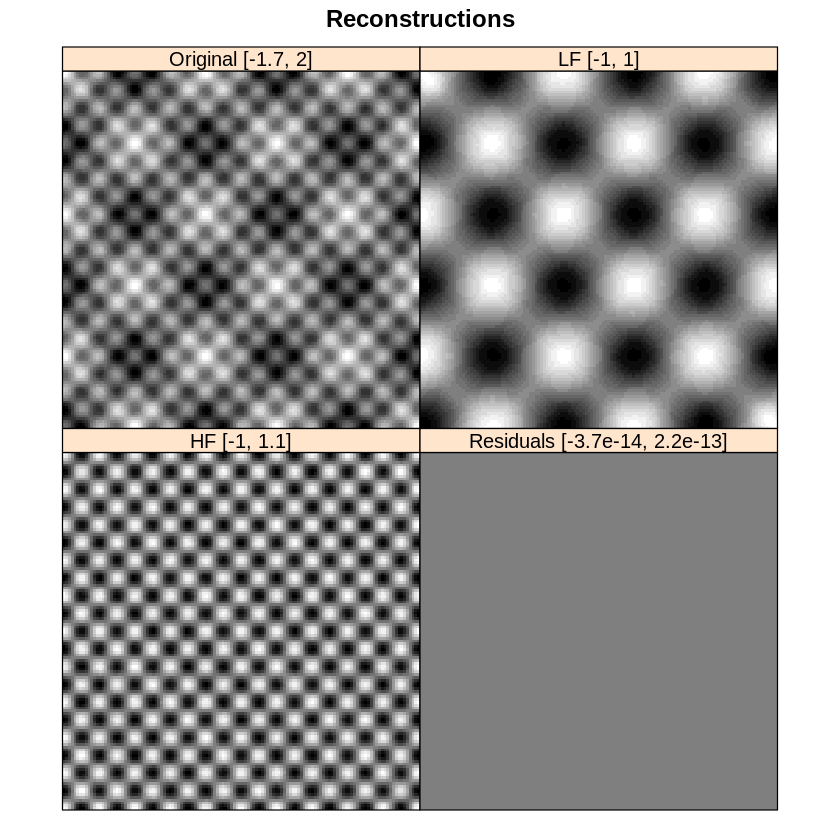

```r
decomprslt<-reconstruct(ssarslt,groups=list(LF=c(4,5,6,7),HF=c(1,2,3,8)))
plot(decomprslt)
```

`-` What if I select a window that is too small?

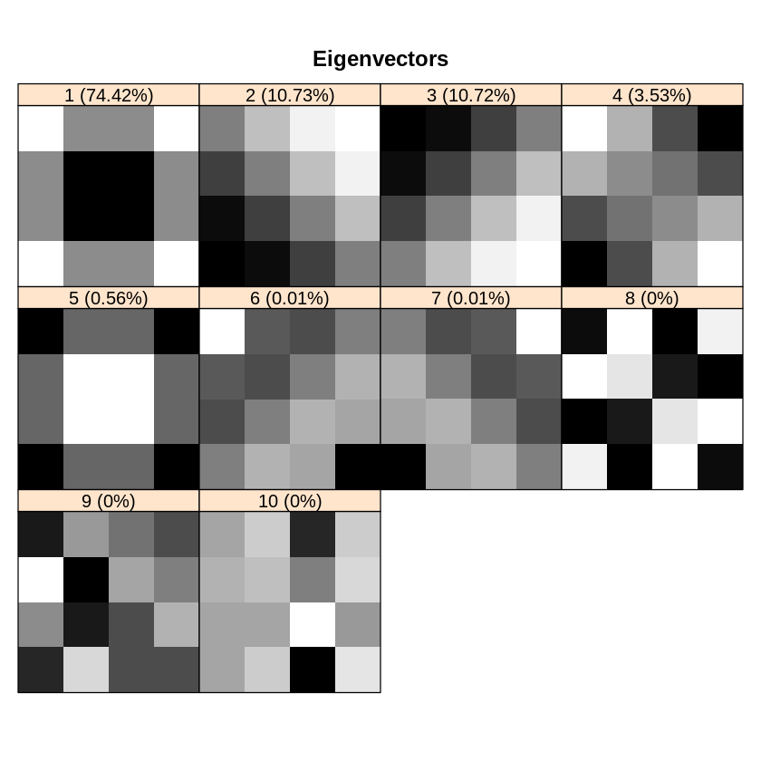

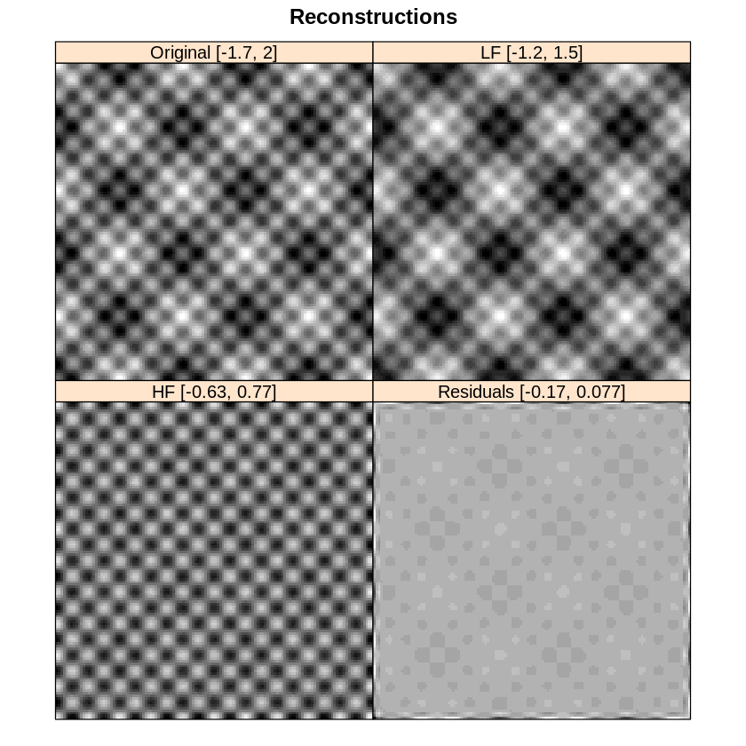

```r
ssarslt<-ssa(cosmeanf, kind="2d-ssa",L=c(4,4))
plot(ssarslt,type="vectors")
decomprslt<-reconstruct(ssarslt,groups=list(LF=c(1,2,3),HF=c(4)))
plot(decomprslt)
```

`-` It is difficult to separate the global structure (low-freq)

**Note:** small window size -> It can’t separate global structure (=low freq) properly -> LF_hat contains some high-frequency signal

### 2D PCA

`-` Reference of 2D PCA is as follows

- Yang, J., Zhang, D., Frangi, A. F., & Yang, J. Y. (2004). Two-dimensional PCA: a new approach to appearance-based face representation and recognition. IEEE transactions on pattern analysis and machine intelligence, 26(1), 131-137.
- ($\ast$) 2D-PCA는 구현된 코드를 찾기 어려워 일단은 임시로 제가 위 논문의 내용을 직접 구현하여 시뮬레이션 하였습니다.

```r
A=cosmeanf
G=t(A-mean(A))%*%(A-mean(A))
svd_<-svd(G)
```

`-` Plot the first 10 eigenvalues

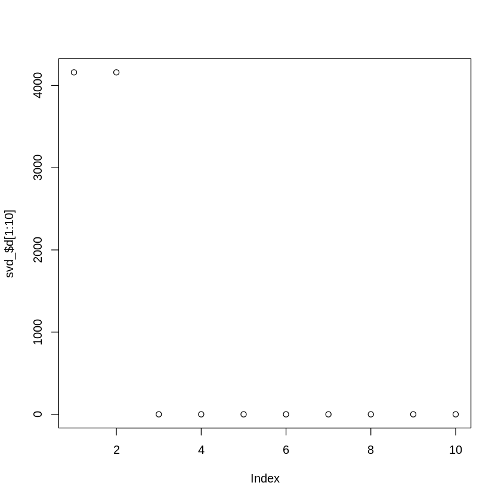

```r
plot(svd_$d[1:10])
```

`-` There are no significant components after the first two eigen values.

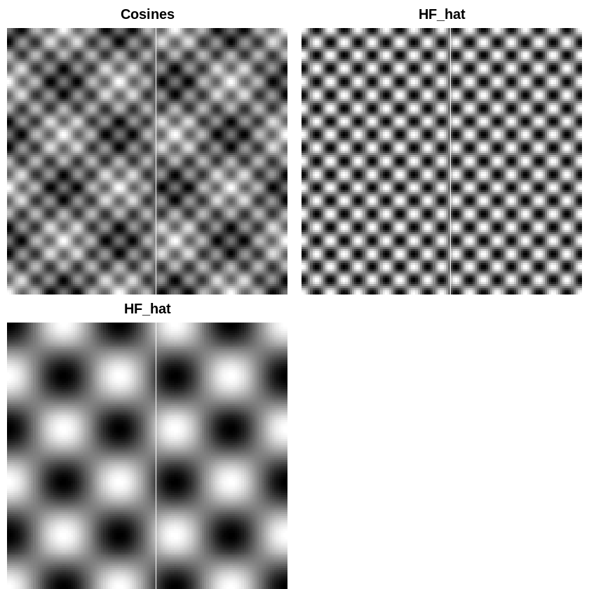

```r
par(mfcol=c(2,2), mar=c(0,0.5,2,0.5))
image(cosmeanf, xlab="", ylab="", col=gray(0:100/100), axes=F, main="Cosines")
#image(coscomp1, xlab="", ylab="", col=gray(0:100/100), axes=F, main="HF_hat")
image(svd_$d[1]*outer(svd_$u[,1], svd_$u[,1] ),xlab="",ylab="", col=gray(0:100/100), axes=F, main="HF_hat")
image(svd_$d[2]*outer(svd_$u[,2], svd_$u[,2] ),xlab="",ylab="", col=gray(0:100/100), axes=F, main="HF_hat")
```

## Testsignal 2

`-` piecewise stationary signal

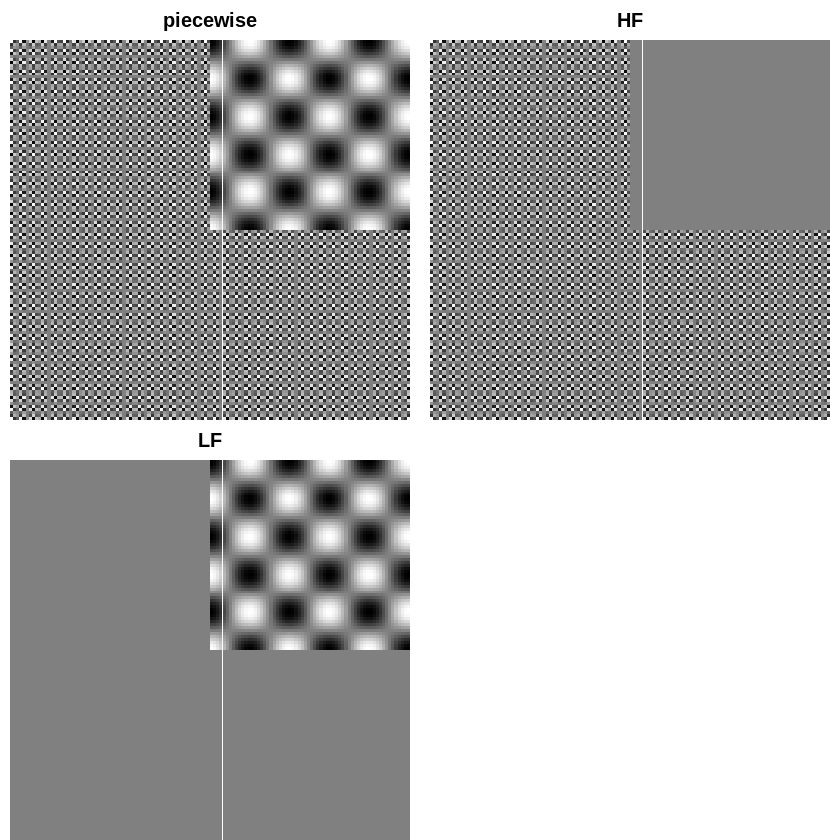

```r
nr <- nc <- 128; x <- y <- seq(0, 1, length=nr)
pcomp1 <- outer(cos(90*pi*x), cos(90*pi*y)); pcomp1[x > 0.5, y > 0.5] <- 0
pcomp2 <- matrix(0, nrow=nr, ncol=nc); pcomp2[x > 0.5, y > 0.5] <- outer(cos(10*pi*x), cos(10*pi*y))[x > 0.5, y > 0.5]
pmeanf <- pcomp1 + pcomp2
par(mfrow=c(2,2), mar=c(0,0.5,2,0.5))
image(pmeanf, xlab="", ylab="", col=gray(0:100/100), axes=F, main="piecewise")
image(pcomp1, xlab="", ylab="", col=gray(0:100/100), axes=F, main="HF")
image(pcomp2, xlab="", ylab="", col=gray(0:100/100), axes=F, main="LF")
```

### SSA

#### window size = (64,64)

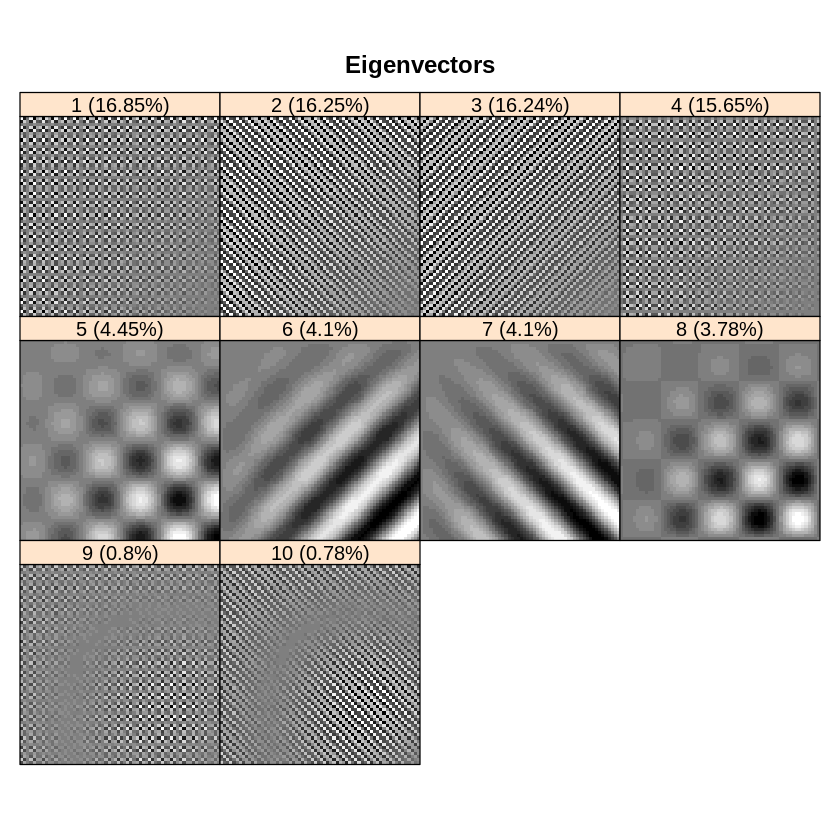

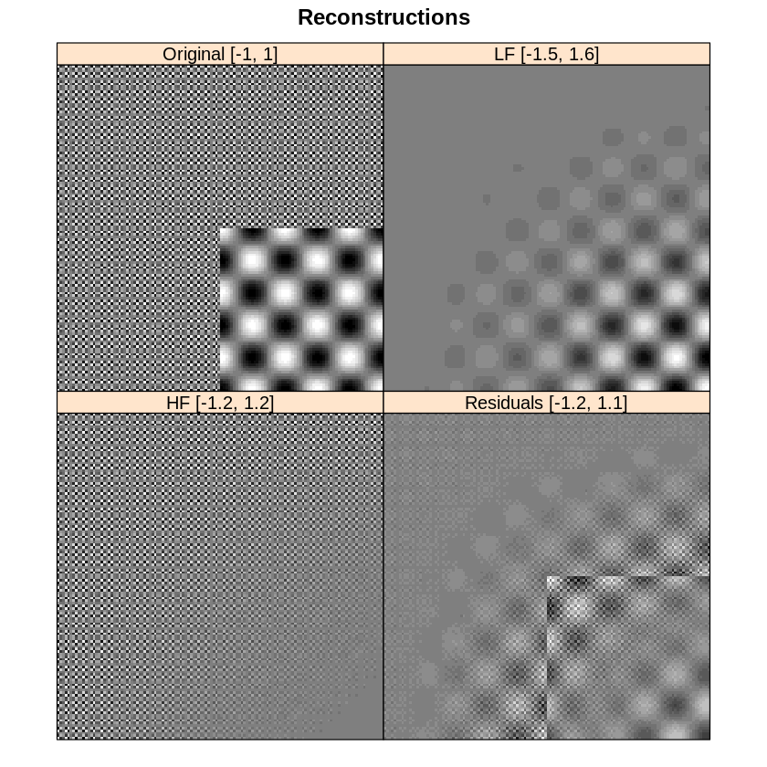

```r
ssarslt<-ssa(pmeanf, kind="2d-ssa",L=c(64,64))
plot(ssarslt,type="vectors")
decomprslt<-reconstruct(ssarslt,groups=list(LF=c(5,6,7,8),HF=c(1,2,3,4)))
plot(decomprslt)
```

**Note:** Large window -> More focus on the global structure -> The point where the frequency fluctuates is smoothed (=distorted) too much

#### window size = (8,8)

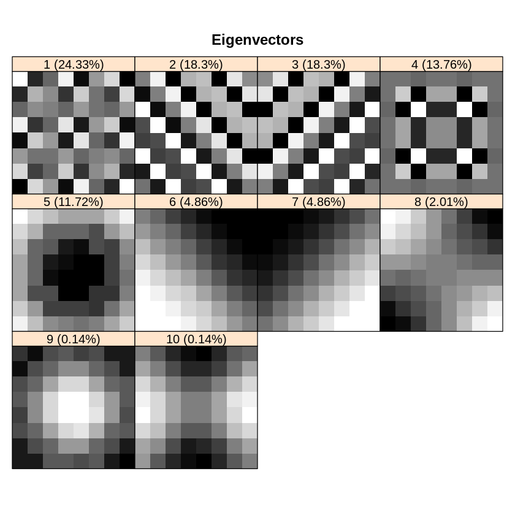

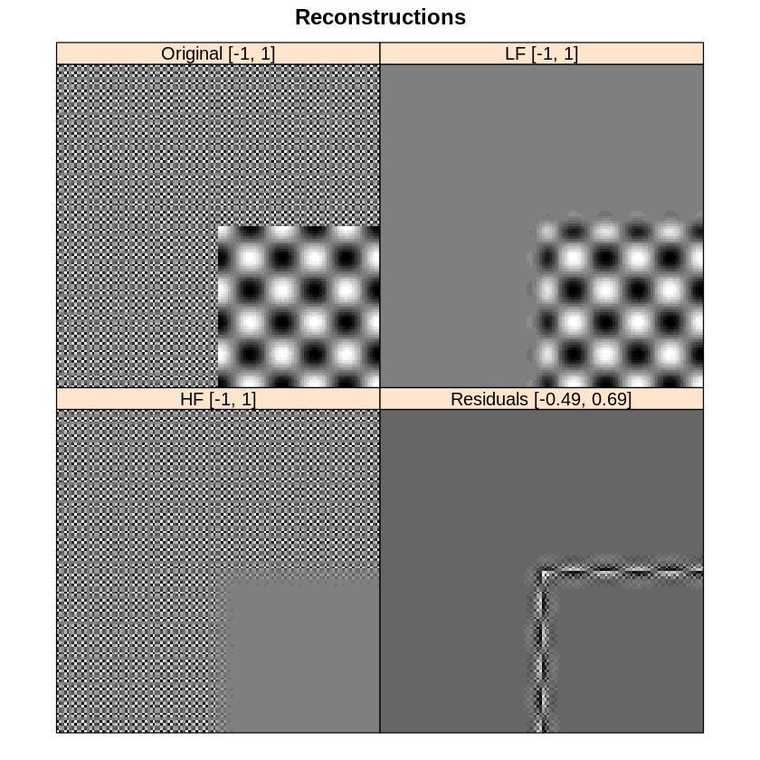

```r
ssarslt<-ssa(pmeanf, kind="2d-ssa",L=c(8,8))
plot(ssarslt,type="vectors")
decomprslt<-reconstruct(ssarslt,groups=list(LF=c(5,6,7,8),HF=c(1,2,3,4)))
plot(decomprslt)
```

`-` We set the window size to 8*8, so it produced an appropriate result.

`-` It is important to choose the appropriate window size.

- The window size must be large enough to properly decompose the global structure (=low freq).
- At the same time, the window should be small enough to sharply detect the area where frequency change occurs.

### 2D-PCA

```r
A=pmeanf
G=t(A-mean(A))%*%(A-mean(A))
svd_<-svd(G)
```

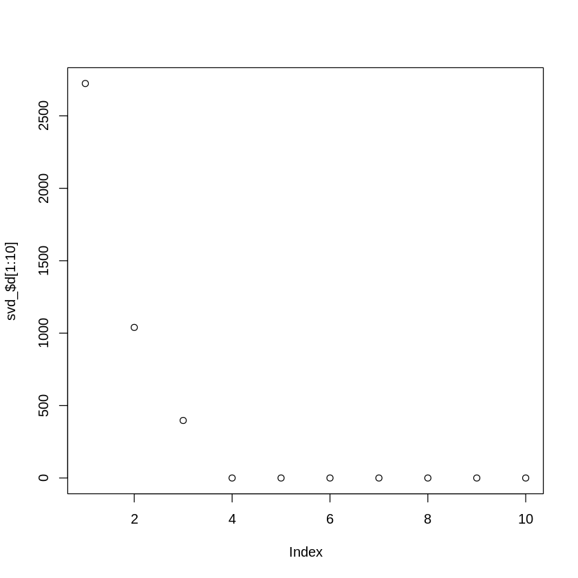

```r
plot(svd_$d[1:10])
```

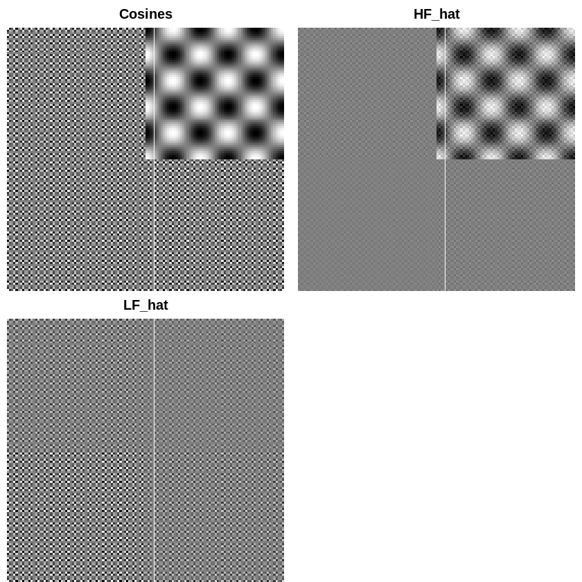

```r
LFhat<- svd_$d[1]*outer(svd_$u[,1], svd_$u[,1])
HFhat<- svd_$d[2]*outer(svd_$u[,2], svd_$u[,2]) + svd_$d[3]*outer(svd_$u[,3], svd_$u[,3])
par(mfcol=c(2,2), mar=c(0,0.5,2,0.5))
image(pmeanf, xlab="", ylab="", col=gray(0:100/100), axes=F, main="Cosines")
image(LFhat,xlab="",ylab="", col=gray(0:100/100), axes=F, main="LF_hat")
image(HFhat,xlab="",ylab="", col=gray(0:100/100), axes=F, main="HF_hat")
```

- High-frequency components and low-frequency components are not properly decomposed.
- 2d pca is not suitable for data with locally stationary.

## TestSignal 3

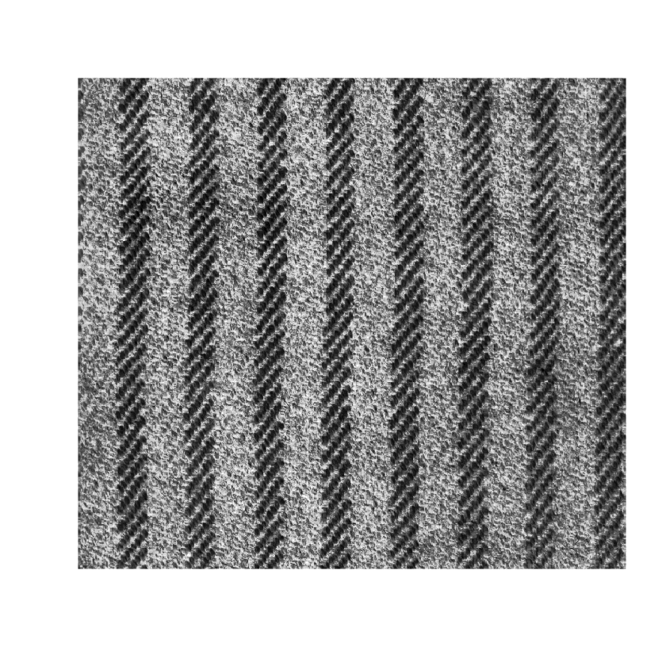

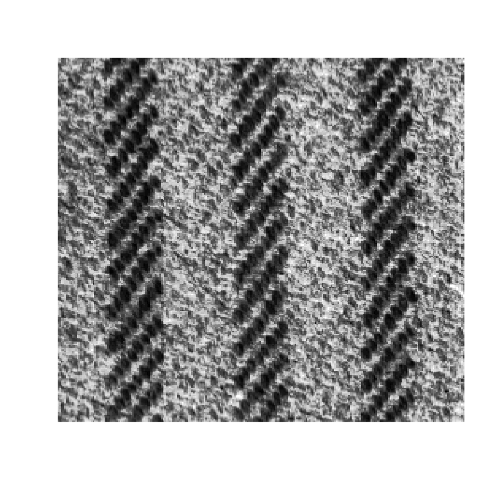

```r
library(tidyverse)
d11 <- as.matrix(read_csv("https://raw.githubusercontent.com/miruetoto/data/main/d11.csv",col_names=FALSE))
image(d11, xlab="", ylab="", col=gray(0:100/100), axes=F, main="")
d11 <- d11[(1+15):(256+15), 1:256]
image(d11, xlab="", ylab="", col=gray(0:100/100), axes=F, main="")
```

### SSA

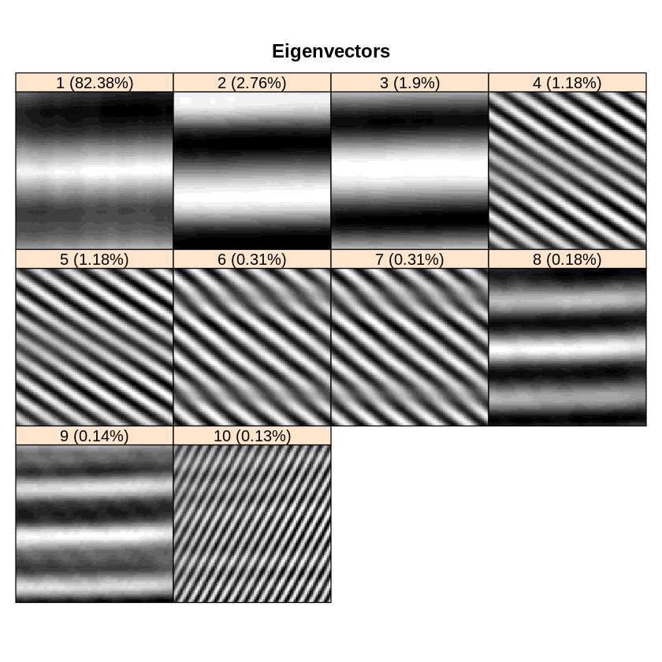

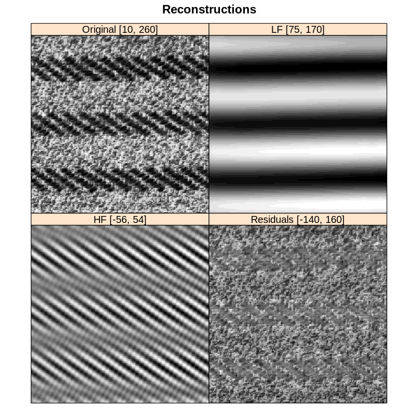

```r
ssarslt<-ssa(d11, kind="2d-ssa",L=c(128,128))
plot(ssarslt,type="vectors")
decomprslt<-reconstruct(ssarslt,groups=list(LF=c(1,2,3),HF=c(4,5,6,7,9,10)))
plot(decomprslt)
```

### 2D-PCA

```r
A=d11
G=t(A-mean(A))%*%(A-mean(A))
svd_<-svd(G)
```

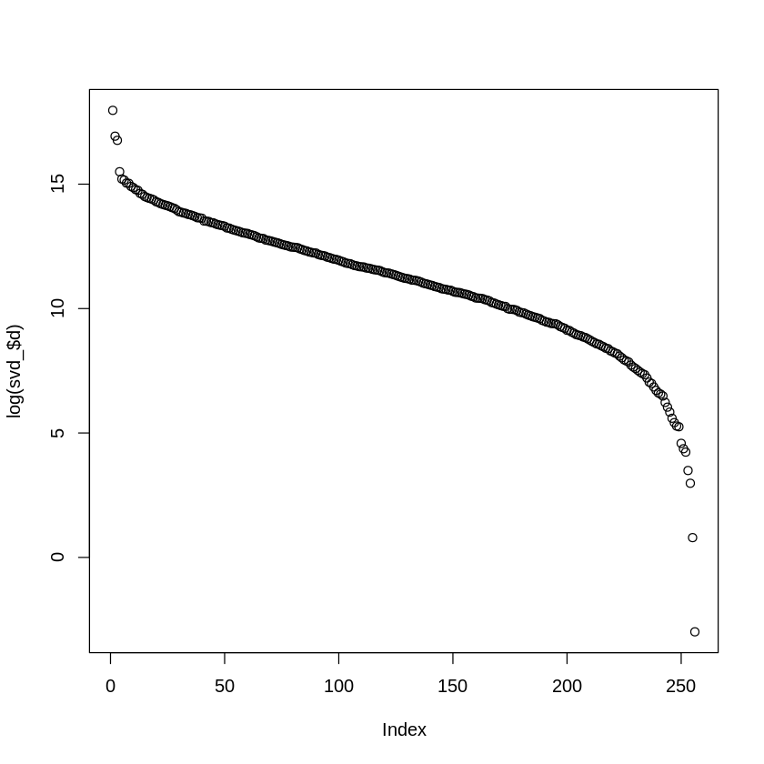

```r
plot(log(svd_$d))
```

`-` It seems that the original image cannot be expressed using a small number of basis.

`-` Components corresponding to the first 9 eigenvalues

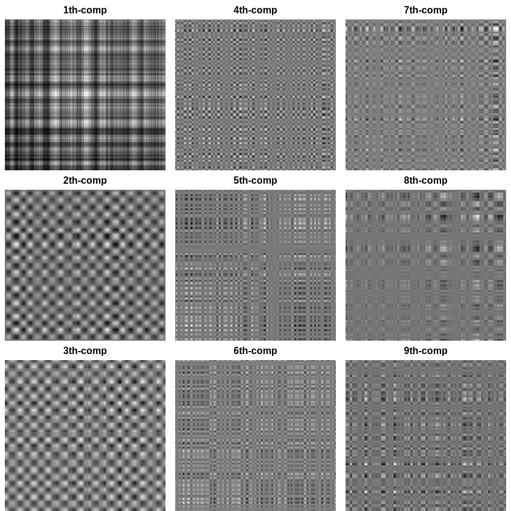

```r
par(mfcol=c(3,3), mar=c(0,0.5,2,0.5))
for(i in 1:9){
    image(svd_$d[i]*outer(svd_$u[,i], svd_$u[,i]),col=gray(0:100/100), axes=F, main=str_c(i,"th-comp"))
}
```

`-` There are no distinct ingredients believed to be high-freq or low-freq. Therefore, there is no choice but to separate the mode somewhat unclear.

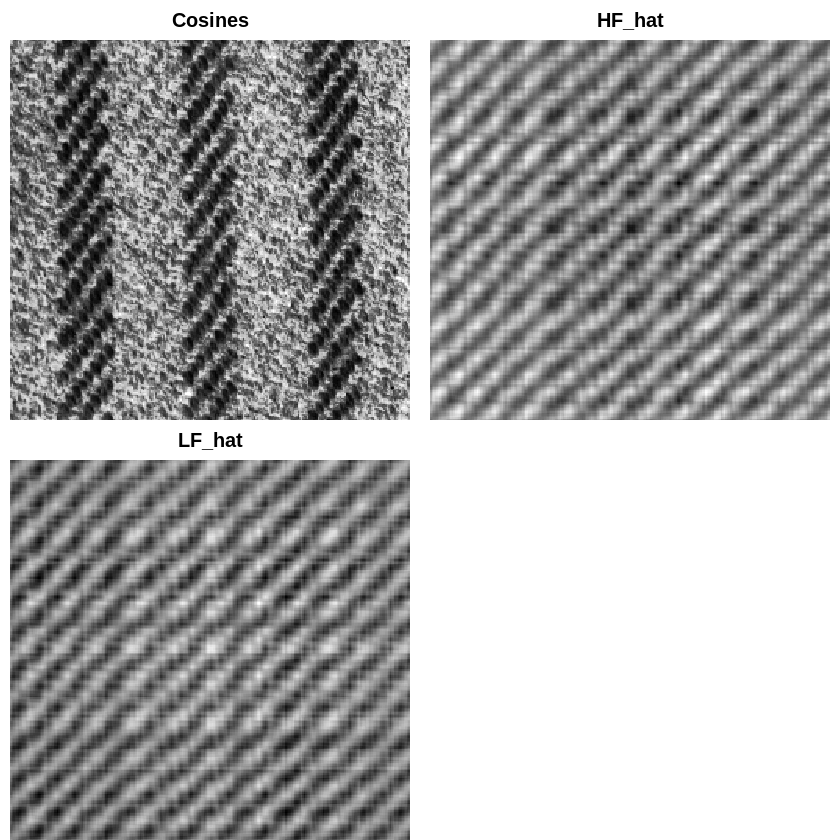

```r
LFhat<- svd_$d[1]*outer(svd_$u[,1], svd_$u[,1]) +svd_$d[2]*outer(svd_$u[,2], svd_$u[,2]) + svd_$d[3]*outer(svd_$u[,3], svd_$u[,3])
HFhat<- d11-LFhat
par(mfcol=c(2,2), mar=c(0,0.5,2,0.5))
image(d11, xlab="", ylab="", col=gray(0:100/100), axes=F, main="Cosines")
image(LFhat,xlab="",ylab="", col=gray(0:100/100), axes=F, main="LF_hat")
image(HFhat,xlab="",ylab="", col=gray(0:100/100), axes=F, main="HF_hat")
```

## Discussion

`-` 제가 각 방법의 차이점을 나름대로 고민하고 분석하여 정리하였습니다.

`-` Comparing decomposition methods

|  | EPT | EMD | DCT | DWT | SSA | PCA |
| --- | --- | --- | --- | --- | --- | --- |
| Decomposition method | Sifiting process | Sifiting process | Spectral analysis | Spectral analysis(?) | Spectral analysis | Spectral analysis |
| Basis | filtered signal (?) | intrinsic mode function | eigenbasis | wavelet | eigenbasis | eigenbasis |
| Emprical method | Yes | Yes | No | No | No | No |
| Locally compact basis | - | - | No | Yes | No | No |
| Multiscale Parameter | Yes | No | No | No | Yes | No |

`-` Decomposition method

- EPT, EMD는 고주파(혹은 저주파)부터 순차적으로 추출; 반면에 DCT, DWT, SSA, PCA는 모든 컴포넌트를 한번에 분해.

`-` Emprical method

- EMD의 IMF는 data-dependent하므로 emprical method로 분류함. (EMD의 IMF는 (1) 전체 데이터 세트에서 극값의 수와 zero-crossing의 수는 같거나 1차이만 나야하며 (2) 어느 시점에서든 로컬 최대 값으로 정의된 엔벨로프와 로컬 최소값으로 정의된 엔벨로프의 평균값 은 0이어야 하는 조건이 있는데 이것이 데이터에 의존함)
- EPT 역시 two-stage filter를 통과한 신호를 component 들로 해석하므로 emprical method로 분류할 수 있음.

`-` Locally compact basis

- DWT는 locally compact한 basis를 가짐 $\to$ DCT, PCA 보다 locally stationary signal의 분석에 유리.

`-` Multiscale Parameter (= window size = patch size)

- Multiscale parameter는 time-resolution과 frequency-resolution 사이의 trade-off를 조절 $\to$ multiscale parameter가 있으면 nonstationary signal에 대한 분석이 유리.
  - EPT는 EMD보다 locally stationary signal을 더 잘 분석함.
  - SSA는 PCA, DCT 보다 locally stationary signal을 더 잘 분석함.